# PGA - Scheffler Greens in Regulation

Confidence Intervals

Binomial Tests

Comparing Two Proportions

Exploring Probability Confidence Intervals with Golf Data

Author

Affiliation

Jonathan Lieb

Baylor University

Published

July 2, 2024

**Facilitation notes**

- This module would be suitable for an in-class lab or take-home assignment in an introductory statistics course.
- It assumes a basic familiarity with the RStudio Environment has already been covered, but no prior programming experiences is expected.
- Students should be provided with the following data file (.csv) and Quarto document (.qmd) to produce visualizations and write up their answers to each exercise. Their final deliverable is to turn in an .html document produced by “Rendering” the .qmd.
  - data
  - Student Quarto template
- [Posit Cloud](https://posit.cloud/) (via an Instructor account) or [Github classroom](https://classroom.github.com) are good options for disseminating files to students, but simply uploading files to your university’s course management system works, too.

# Welcome video

[interactive chart not shown]

# Introduction

In this module, you will be exploring the concept of confidence intervals for proportions through the lens of golf. Specifically, you will be analyzing the 2023 greens in regulation data for Scottie Scheffler. Scottie Scheffler was the number 1 ranked golfer in the world and the PGA Tour Player of the Year in 2023.

Scottie Scheffler

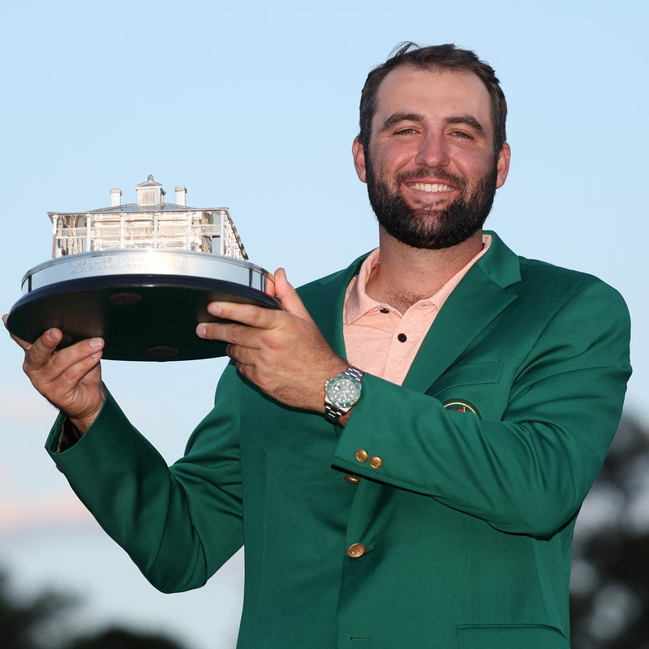

Image source: [Official World Golf Rankings](https://www.owgr.com/playerprofile/scottie-scheffler-18417)

**Learning Objectives**

By the end of this module, you will be able to:

- Read (import) a dataset into your RStudio Environment
- Mutate and arrange data in R
- Use R to make confidence intervals for a proportion
- Perform a hypothesis test to compare proportions

**NOTE**: **R** is the name of the programming language itself and **RStudio** is a convenient interface. To throw even more lingo in, you may be accessing RStudio through a web-based version called **Posit Cloud**. But R is the programming language you are learning

**Research Questions**

During this lab, you’ll investigate the following research questions:

- What is the probability that Scottie Scheffler hits the green in regulation in 2023 from different lies?
- What is the confidence interval for the probability that Scottie Scheffler hits the green in regulation in 2023 from different lies?
- Is there a significant difference in the probability that Scottie Scheffler hits the green in regulation in 2023 from different lies?

# Getting started: Scottie Scheffler Greens data

The first step to any analysis in R is to **load necessary packages and data**.

You can think of **packages** like apps on your phone; they extend the functionality and give you access to many more features beyond what comes in the “base package”.

Running the following code will load the `tidyverse` and packages and the `scheffler_2023` data we will be using in this lab.

**TIP**: As you follow along in the lab, you should run each corresponding code chunk in your .qmd document. To “Run” a code chunk, you can press the green “Play” button in the top right corner of the code chunk in your .qmd. You can also place your cursor anywhere in the line(s) of code you want to run and press “command + return” (Mac) or “Ctrl + Enter” (Windows).

**TIP**: Using a hashtag in R allows you to add comments to your code (in plain English).

```r
library(tidyverse) #loads package

scheffler_2023 <- read_csv("scheffler_2023.csv") #loads data
```

We can use the `glimpse()` function to get a quick look at our `scheffler_2023` data. The `glimpse` code provides the number of observations (Rows) and the number of variables (Columns) in the dataset. The “Rows” and “Columns” are referred to as the **dimensions** of the dataset. It also shows us the names of the variables (`player`, `greens`, `holes` …, `cut`) and the first few observations for each variable.

```r
glimpse(scheffler_2023)
```

```
Rows: 3
Columns: 5
$ player <chr> "Scottie Scheffler", "Scottie Scheffler", "Scottie Scheffler"
$ year   <dbl> 2023, 2023, 2023
$ greens <dbl> 247, 657, 28
$ holes  <dbl> 416, 760, 48
$ cut    <chr> "Other", "Fairway", "Bunker"
```

Another useful function to get a quick look at the data is the `head()` function. This function shows the first few rows of the dataset.

```r
head(scheffler_2023)
```

```
# A tibble: 3 × 5
  player             year greens holes cut
  <chr>             <dbl>  <dbl> <dbl> <chr>
1 Scottie Scheffler  2023    247   416 Other
2 Scottie Scheffler  2023    657   760 Fairway
3 Scottie Scheffler  2023     28    48 Bunker
```

**Exercise 1: Data Structure**

1. What are the **dimensions** of this dataset?
2. Are there any **variables** not useful for our analysis? If so, list the names of these variables.
3. What **type of variable** (ex: continuous numeric, catergorical, binary, ordinal…) is the `cut` **variable**?
4. Which two **variables** can be used to calculate the proportion of greens hit in regulation?

**TIP:** Type your answers to each exercise in the .qmd document.

## Terms to know

Before proceeding with the analysis, let’s make sure we know some golf terminology that will help us putt-putt our way through this lab.

Are Greens in Regulation important to scoring? Check out the table below to see how greens in regulation and lower handicaps go hand and hand

[figure not shown]

Image source: [The Range by The Grint](https://thegrint.com/range/2013/03/golf-tips-gir/)

A Par 3 hole should take 1 shot to reach the green in regulation

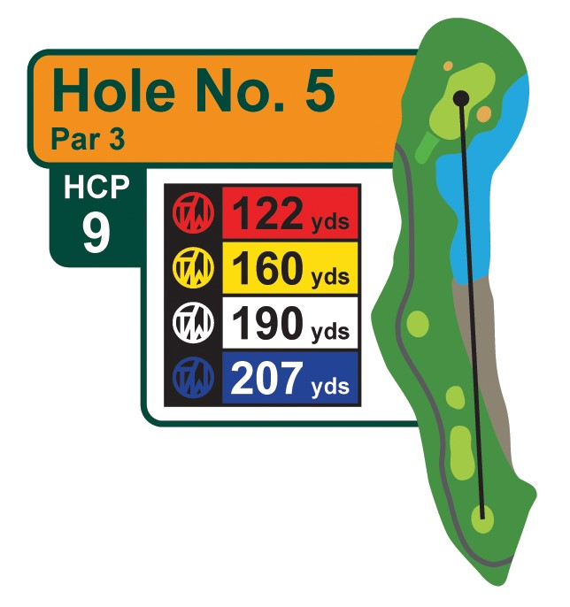

A Par 4 hole should take 2 shots to reach the green in regulation

[figure not shown]

A Par 5 hole should take 3 shots to reach the green in regulation

[figure not shown]

Images source: [Tanglewood Golf Course](https://www.tanglewoodfulton.com/golf-course/hole-by-hole-layout)

#### Lie Terminology

- The **fairway** is the short grass between the tee box and the green, where the ball is supposed to be hit on a par 4 or par 5 hole
- A **bunker** is a hazard filled with sand
  - A **fairway bunker** is a bunker located in or next to the fairway

**Pars and Greens in Regulation**

- A **par** in golf is the number of strokes a good golfer is expected to make on a hole or course
- A **green in regulation** (GIR) is when a golfer reaches the green in the expected number of strokes (or fewer) on a par 3, 4, or 5 hole
  - For example, on a **par 4** hole, a golfer would be expected to reach the green in 2 strokes (a drive and an approach shot) and then putt out in 2 more strokes for a total of 4 strokes. If a golfer reaches the green in 2 strokes, they have hit the green in regulation.
  - On a **par 3** hole, a golfer would be expected to reach the green in 1 stroke
  - On a **par 5** hole, a golfer would be expected to reach the green in 3 strokes.

## Variable descriptions

The `scheffler_2023` data you’ll be analyzing in this lab provides approach data for Scottie Scheffler in 2023. The data includes the number of greens in regulation (GIR) hit by Scottie Scheffler, the number of holes he played, and the cut he hit from.

**Variable Descriptions**

| Variable | Description |
| --- | --- |
| `player` | PGA Tour player |
| `year` | PGA Tour Season |
| `greens` | Greens in Regulation Hit |
| `holes` | Number of Holes |
| `cut` | The type of ground that the approach shot to the green was hit from |

## Mutating Data

1. Mutating data in R is the process of creating new variables based on existing variables in a dataset. This can be done using the `mutate()` function in the `dplyr` package.
2. The mutate function takes a data frame as its first argument and then a series of new variable assignments. (Eg: `mutate(data, new_var1 = old_var * 2, new_var = old_var1 - old_var2)`)

## Arranging Data

1. The `arrange()` function in the `dplyr` package is used to sort the data frame by one or more variables.
2. The `arrange()` function takes a data frame as its first argument and then a series of variables to sort by. (Eg: `arrange(data, variable1, variable2)`)
3. By default, the `arrange()` function sorts in ascending order. To sort in descending order, you can use the `desc()` function inside the `arrange()` function. (Eg: `arrange(data, desc(variable1))`)

**Exercise 2: Data Manipulation**

Use the `mutate()` function to create a new variable called `gir_rate` that represents the proportion of greens hit in regulation. Save this new dataset as `scheffler_2023_mutated`. Then arrange the `scheffler_2023_mutated` data by the `gir_rate` variable in descending order.

1. From what `cut` did Scottie Scheffler have the best Green in Regulation rate?
2. From what `cut` did Scottie Scheffler have the worst Green in Regulation rate?

# Confidence Intervals for Proportions

Confidence Intervals for Proportions can be used for a variety of purposes, including:

1. A confidence interval is a range of values that is likely to contain the true value of a population parameter with a certain level of confidence.
2. Confidence intervals help us to quantify the precision of our estimates. The wider the confidence interval, the less precise our estimate is, the narrower the confidence interval, the more precise our estimate is.
3. Inferences can be made about the population proportion based on the sample proportion when using confidence intervals. For example, if a 90% confidence interval was used, it could be said that if the same population was sampled on numerous occasions and interval estimates were made on each occasion, approximately 90% of the intervals would contain the population parameter.
4. Confidence intervals for proportions can be used to test hypothesized values of the population proportion. If the hypothesized value is not within the confidence interval, then the null hypothesis can be rejected.
5. Confidence intervals for proportions can be used to compare two proportions. If the confidence intervals for two proportions do not overlap, then the two proportions are significantly different.

## Making Confidence Intervals in R

The statistical notation for a confidence interval for a proportion is:

$$\hat{p} \pm z \times \sqrt{\frac{\hat{p}(1-\hat{p})}{n}}$$

Where:

- $\hat{p}$ is the sample proportion.
- $z$ is the z-score that corresponds to the desired level of confidence
- $n$ is the sample size

**TIP**: The z-score for a 95% confidence interval is approximately 1.96. You can use this value to calculate the confidence interval for the proportion of greens hit in regulation by Scottie Scheffler from the fairway.

Some common Confidence Intervals and their corresponding z-scores are:

| Confidence Interval | Z-Score |
| --- | --- |
| 90 % | 1.65 |
| 95 % | 1.96 |
| 98 % | 2.33 |
| 99 % | 2.58 |

In R you can perform basic math using the `*` operator for multiplication and the `\` operator for division.

For a quick example if proportion of success for a problem is .6, the sample size is 100, and the test is being performed at the 95% confidence level than the confidence interval for the proportion of success can be calculated as follows:

```r
lower_limit <- .6 - 1.96 * sqrt((.6 * (1-.6))/100)
upper_limit <- .6 + 1.96 * sqrt((.6 * (1-.6))/100)
```

This would give you the lower limit (0.50398) and upper limit (0.69602) of the confidence interval for the proportion of success.

**Exercise 3: Manual Confidence Intervals**

Use the numbers from row with **`cut` = “Fairway”** of the `scheffler_2023_mutated` dataset to calculate a **95% confidence interval** for the proportion of greens hit in regulation by Scottie Scheffler from the fairway.

1. What is value of $\hat{p}$ for the fairway cut?
2. What is the value of $n$ for the fairway cut?
3. What is the estimated value of the **upper limit** of the confidence interval for the fairway cut?
4. What is the estimated value of the **lower limit** of the confidence interval for the fairway cut?

## Using `binom.test` to Calculate Confidence Intervals

In R the `binom.test()` function can be used to calculate confidence intervals for proportions. The `binom.test()` function takes the number of successes and the total number of trials as arguments and returns a confidence interval for the proportion.

**TIP**: You can type `?binom.test` in the R console to get more information about the `binom.test()` function, including which arguments it takes and what it returns.

```r
binom.test(60, 100, conf.level = .98)
```

```
    Exact binomial test

data:  60 and 100
number of successes = 60, number of trials = 100, p-value = 0.05689
alternative hypothesis: true probability of success is not equal to 0.5
98 percent confidence interval:
 0.4789036 0.7129194
sample estimates:
probability of success
                   0.6
```

```r
binom.test(60, 100, conf.level = .98)$conf.int
```

```
[1] 0.4789036 0.7129194
attr(,"conf.level")
[1] 0.98
```

**Exercise 4: Using R Functions for Confidence Intervals**

Use the `binom.test()` function to calculate a **95% confidence interval** for the proportion of greens hit in regulation by Scottie Scheffler from the **bunker**.

1. What is the value of the **lower limit** of the confidence interval for the bunker cut?
2. What is the value of the **upper limit** of the confidence interval for the bunker cut?
3. Is the range of the confidence interval for the **bunker** cut wider or narrower than the range of the confidence interval for the **fairway** cut?

## Testing Hypothesized Values

Hypothesis testing can also be done using the `binom.test()` function as seen below where it is being tested if the proportion of successes is .7 for a sample size of 100. The `binom.test()` function returns the p-value of the test.

```r
binom.test(60, 100, p = .7)
```

```
    Exact binomial test

data:  60 and 100
number of successes = 60, number of trials = 100, p-value = 0.03745
alternative hypothesis: true probability of success is not equal to 0.7
95 percent confidence interval:
 0.4972092 0.6967052
sample estimates:
probability of success
                   0.6
```

Suppose you are watching a golf tournament on TV and Scottie Scheffler is about to hit an approach shot from the fairway. You hear the announcer say that Scottie Scheffler hits 3/4 of his greens in regulation from the fairway. You are skeptical of this claim and decide to test it against the data you have collected at the 95% confidence level.

You set up a hypothesis test with the following hypotheses:

- **Null Hypothesis $H_0$**: The proportion of greens hit in regulation by Scottie Scheffler from the fairway is 0.75.
- **Alternative Hypothesis $H_A$**: The proportion of greens hit in regulation by Scottie Scheffler from the fairway is not 0.75.

**Exercise 5: Confidence Intervals for Hypothesis Testing**

Use the `binom.test()` function to test the hypothesis that the proportion of greens hit in regulation by Scottie Scheffler from the fairway is 0.75.

1. What is the value of the test statistic?
2. What is the p-value of the test?
3. Based on the p-value, do you reject or fail to reject the null hypothesis?

# Comparing Two Proportions

Sometimes, comparing two sample proportions is necessary to determine if they are significantly different. This can be done with a two sample z-test for equality of proportions.

The null hypothesis for a two sample z-test for equality of proportions is that the two proportions are equal.

$H_0: p_1 = p_2$

The alternative hypothesis can be that the two proportions are not equal.

$H_A: p_1 \neq p_2$

That the first proportion is greater than the second proportion.

$H_A: p_1 > p_2$

or that the first proportion is less than the second proportion.

$H_A: p_1 < p_2$

The test-statistic for the two sample z-test for equality of proportions is calculated as:

$Z = \frac{\hat{p}_1 - \hat{p}_2}{\sqrt{\hat{p}(1-\hat{p})\left(\frac{1}{n_1} + \frac{1}{n_2}\right)}}$

where

$\hat{p}_1$ and $\hat{p}_2$ are the sample proportions for the two samples,

$\hat{p}$ is the pooled proportion,

$n_1$ and $n_2$ are the sample sizes for the two samples.

The pooled proportion is calculated as:

$\hat{p} = \frac{x_1 + x_2}{n_1 + n_2}$

**TIP**:Use the `?prop.test` command in the R console to get more information about the `prop.test()` function, including which arguments it takes and what it returns.

**NOTE**: `prop.test` can take the form `prop.test(c(x1, x2), c(n1, n2))` where `x1` and `x2` are the number of successes in each sample and `n1` and `n2` are the total number of trials in each sample. It can also take the form `prop.test(matrix(c(x1, x2, n1, n2), ncol = 2))` where `x1` and `x2` are the number of successes in each sample and `n1` and `n2` are the total number of trials in each sample.

**NOTE**: The confidence level can be adjusted using the `conf.level` argument and the type of alternative hypothesis can be adjusted using the `alternative` argument.

Below is an example of how the `prop.test()` function could be used to compare two proportions:

```r
prop.test(c(10, 20), c(100, 100), alternative = 't', correct = FALSE)
```

```
    2-sample test for equality of proportions without continuity correction

data:  c(10, 20) out of c(100, 100)
X-squared = 3.9216, df = 1, p-value = 0.04767
alternative hypothesis: two.sided
95 percent confidence interval:
 -0.197998199 -0.002001801
sample estimates:
prop 1 prop 2
   0.1    0.2
```

The example above compares two proportions: 10 successes out of 100 trials in the first sample and 20 successes out of 100 trials in the second sample. The `prop.test()` function returns a p-value for the comparison, which in this case is .048.

**Exercise 6: Comparing Two Proportions**

Of the cuts in golf, the **fairway** is generally considered to be the most desirable place to hit the ball. Shorter grass is widely believed to make it easier to hit the green in regulation.

The **bunker**, on the other hand, is often considered to be one of the most difficult places to hit the ball from. The sand can make it difficult to control the ball and hit it accurately. Additionally, no practice swings are allowed to hit the sand in the **bunker** making it more difficult to get a feel for the shot.

In the `scheffler_2023` dataset there is also a cut called **“Other”**. This includes shots from the rough, waste areas, mulch and more. These are also often expected to be tougher than the fairway but slightly easier to hit out of than bunkers, but not always. Our summarization of the probabilities from different cuts earlier confirmed a slightly higher probability of hitting the green in regulation from the **“Other”** cut compared to the bunker cut.

Use the `prop.test()` function to compare the proportion of greens hit in regulation by Scottie Scheffler from the **fairway** and the **bunker**. Make the alternative hypothesis that the proportion of greens hit in regulation from the fairway is greater than the proportion of greens hit in regulation from the bunker. Use the **95% confidence level**. Set **correct = FALSE**.

1. What is the value of the test statistic?
2. What is the p-value of the test?
3. Is 0 included in the confidence interval for the difference in proportions?
4. Based on your answers above, what is your conclusion about the comparison of the two proportions?
5. Is there enough evidence to suggest that it is better for Scottie Scheffler to hit from the fairway than from the bunker?

Use the `prop.test()` function to compare the proportion of greens hit in regulation by Scottie Scheffler from the **Other** cut and the **Bunker**. Make the alternative hypothesis that the proportion of greens hit in regulation from the Other cut is greater than the proportion of greens hit in regulation from the bunker. Use the **95% confidence level**. Set **correct = FALSE**.

6. What is the value of the test statistic?
7. What is the p-value of the test?
8. Is 0 included in the confidence interval for the difference in proportions?
9. Based on your answers above, what is your conclusion about the comparison of the two proportions?
10. Is there enough evidence to reject the null hypothesis and suggest that it is better for Scottie Scheffler to hit from the “Other” cut than from bunker?

Click Below to see more about rules about hitting out of the bunkers in golf: [Bunker Rules Explained](https://www.youtube.com/watch?v=T9_gXqAE6ZY)

# More Practice

**Challenge Problems**

Scottie Scheffler is not the only great golfer on the PGA Tour. In the pga_girs dataset there is data on the greens hit in regulation by PGA professionals from 2019-2023. The data is structured identically to the `scheffler_2023` dataset.

**Challenge 1: Two Player Comparison**

1. Compare Scottie Scheffler’s approach shots to Rory McIlroy’s approach shots in 2023.
   1. Use the `prop.test()` function to compare the proportion of greens hit in regulation by Scottie Scheffler from the **fairway** to the proportion of greens hit in regulation by Rory McIlroy from the **fairway**. Make the alternative hypothesis that the proportion of greens hit in regulation from the fairway by Scottie Scheffler is greater than the proportion of greens hit in regulation from the fairway by Rory McIlroy. Use the **95% confidence level**. Set **correct = FALSE**.
   2. Is Scottie Scheffler statistically better than Rory McIlroy at hitting greens in regulation from the fairway? Explain your answer.
   3. Compare the proportion of greens hit in regulation by Scottie Scheffler from the **bunker** to the proportion of greens hit in regulation by Rory McIlroy from the **bunker**. Make the alternative hypothesis that the proportion of greens hit in regulation from the bunker by Scottie Scheffler is greater than the proportion of greens hit in regulation from the bunker by Rory McIlroy. Use the **95% confidence level**. Set **correct = FALSE**.
   4. Is Scottie Scheffler statistically better than Rory McIlroy at hitting greens in regulation from the bunker? Explain your answer.
   5. Explain why it might be more difficult to find a significant difference in the proportion of greens hit in regulation from the bunker compared to the fairway.

**Challenge 2: Past Comparisons**

2. Scottie Scheffler skyrocketed up the world golf rankings from 2019-2023. His world golf ranking went from 66 to 31 to 12 to 2 and finally to number 1 (at the end of each season respectively). Take a look at whether Scottie Scheffler’s Greens in Regulation from different cuts improved during his climb to the top. Filter the `pga_girs` dataset to only include data from Scottie Scheffler in 2019, 2020, 2021, 2022, and 2023.
   1. Use filter, mutate, and arrange to calculate Scheffler’s GIR from the fairway each season. Which season is it the highest?
   2. Which season is it the lowest?
   3. Use the `prop.test()` function to compare the proportion of greens hit in regulation by Scottie Scheffler from the **fairway** in 2019 to the proportion of greens hit in regulation by Scottie Scheffler from the **fairway** in 2020 Make the alternative hypothesis that the proportion of greens hit in regulation from the fairway by Scottie Scheffler in 2019 is less than the proportion of greens hit in regulation from the fairway by Scottie Scheffler in 2020. Use the **95% confidence level**. Set **correct = FALSE**.
   4. Use the `prop.test()` function to compare the proportion of greens hit in regulation by Scottie Scheffler from the **Other** cut in 2021 to the proportion of greens hit in regulation by Scottie Scheffler from the **Other** cut in 2022. Make the alternative hypothesis that the proportion of greens hit in regulation from the fairway by Scottie Scheffler in 2021 is less than the proportion of greens hit in regulation from the fairway by Scottie Scheffler in 2022. Use the **95% confidence level**. Set **correct = FALSE**.

**Challenge 3: Changing Conditions**

3. Find the best and worst bunker players in 2023 who took more than 50 approach shots from the bunker.
   1. Test the hypothesis that the proportion of greens hit in regulation from the bunker by the best bunker player is greater than the proportion of greens hit in regulation from the bunker by the worst bunker player. Use the **90% confidence level**. Set **correct = FALSE**.
   2. Test the hypothesis that the proportion of greens hit in regulation from the fairway by the best bunker player is greater than the proportion of greens hit in regulation from the fairway by the worst bunker player. Use the **99% confidence level**. Set **correct = TRUE**.
   3. Do you get differing results when you change the confidence level and add a continuity correction? If yes, explain why.

Rory McIlroy is one of the most popular and best golfers on the PGA Tour. He has won multiple major championships. He is known for his long drives and his picturesque swing.

Rory McIlroy

[figure not shown]

Image Source: [Official World Golf Rankings](https://www.owgr.com/playerprofile/rory-mcilroy-10091)

When **correct = TRUE** on the `prop.test()` function, a continuity correction is applied to the test statistic. This correction is used to make the discrete data more continuous. It also generally makes the test more conservative. The formula for the test statistic is below:

$$X^2 = (\frac{\left|\hat{p}_1 - \hat{p}_2\right| - .5(\frac{1}{n_1} + \frac{1}{n_2})}{\sqrt{\hat{p}(1-\hat{p}(\frac{1}{n_1} + \frac{1}{n_2}}})^2$$